# Risk Factor Analysis

## Outcome Variable

**Outcome Variable:** wasted

## Predictor Variables

**Intervention Variable:** feducyrs

**Adjustment Set:**

unadjusted

## Stratifying Variables

The analysis was stratified on these variable(s):

- agecat
- studyid
- country

## Data Summary

| agecat | studyid | country | feducyrs | wasted | n_cell | n |
| --- | --- | --- | --- | --- | --- | --- |
| Birth | ki0047075b-MAL-ED | BANGLADESH | High | 0 | 40 | 119 |
| Birth | ki0047075b-MAL-ED | BANGLADESH | High | 1 | 4 | 119 |
| Birth | ki0047075b-MAL-ED | BANGLADESH | Low | 0 | 25 | 119 |
| Birth | ki0047075b-MAL-ED | BANGLADESH | Low | 1 | 8 | 119 |
| Birth | ki0047075b-MAL-ED | BANGLADESH | Medium | 0 | 35 | 119 |
| Birth | ki0047075b-MAL-ED | BANGLADESH | Medium | 1 | 7 | 119 |
| Birth | ki0047075b-MAL-ED | INDIA | High | 0 | 6 | 23 |
| Birth | ki0047075b-MAL-ED | INDIA | High | 1 | 1 | 23 |
| Birth | ki0047075b-MAL-ED | INDIA | Low | 0 | 11 | 23 |
| Birth | ki0047075b-MAL-ED | INDIA | Low | 1 | 2 | 23 |
| Birth | ki0047075b-MAL-ED | INDIA | Medium | 0 | 3 | 23 |
| Birth | ki0047075b-MAL-ED | INDIA | Medium | 1 | 0 | 23 |
| Birth | ki0047075b-MAL-ED | NEPAL | High | 0 | 2 | 9 |
| Birth | ki0047075b-MAL-ED | NEPAL | High | 1 | 1 | 9 |
| Birth | ki0047075b-MAL-ED | NEPAL | Low | 0 | 3 | 9 |
| Birth | ki0047075b-MAL-ED | NEPAL | Low | 1 | 0 | 9 |
| Birth | ki0047075b-MAL-ED | NEPAL | Medium | 0 | 3 | 9 |
| Birth | ki0047075b-MAL-ED | NEPAL | Medium | 1 | 0 | 9 |
| Birth | ki0047075b-MAL-ED | PERU | High | 0 | 83 | 190 |
| Birth | ki0047075b-MAL-ED | PERU | High | 1 | 1 | 190 |
| Birth | ki0047075b-MAL-ED | PERU | Low | 0 | 55 | 190 |
| Birth | ki0047075b-MAL-ED | PERU | Low | 1 | 1 | 190 |
| Birth | ki0047075b-MAL-ED | PERU | Medium | 0 | 48 | 190 |
| Birth | ki0047075b-MAL-ED | PERU | Medium | 1 | 2 | 190 |
| Birth | ki0047075b-MAL-ED | SOUTH AFRICA | High | 0 | 10 | 33 |
| Birth | ki0047075b-MAL-ED | SOUTH AFRICA | High | 1 | 0 | 33 |
| Birth | ki0047075b-MAL-ED | SOUTH AFRICA | Low | 0 | 13 | 33 |
| Birth | ki0047075b-MAL-ED | SOUTH AFRICA | Low | 1 | 1 | 33 |
| Birth | ki0047075b-MAL-ED | SOUTH AFRICA | Medium | 0 | 9 | 33 |
| Birth | ki0047075b-MAL-ED | SOUTH AFRICA | Medium | 1 | 0 | 33 |

[output cut: 300 more lines]

The following strata were considered:

- agecat: 24 months, studyid: ki0047075b-MAL-ED, country: BANGLADESH
- agecat: 24 months, studyid: ki0047075b-MAL-ED, country: INDIA
- agecat: 24 months, studyid: ki0047075b-MAL-ED, country: NEPAL
- agecat: 24 months, studyid: ki0047075b-MAL-ED, country: PERU
- agecat: 24 months, studyid: ki0047075b-MAL-ED, country: SOUTH AFRICA
- agecat: 24 months, studyid: ki0047075b-MAL-ED, country: TANZANIA, UNITED REPUBLIC OF
- agecat: 24 months, studyid: ki1017093b-PROVIDE, country: BANGLADESH
- agecat: 24 months, studyid: ki1017093c-NIH-Crypto, country: BANGLADESH
- agecat: 24 months, studyid: ki1066203-TanzaniaChild2, country: TANZANIA, UNITED REPUBLIC OF
- agecat: 24 months, studyid: ki1113344-GMS-Nepal, country: NEPAL
- agecat: 24 months, studyid: ki1119695-PROBIT, country: BELARUS
- agecat: 24 months, studyid: ki1126311-ZVITAMBO, country: ZIMBABWE
- agecat: 24 months, studyid: ki1135781-COHORTS, country: GUATEMALA
- agecat: 24 months, studyid: ki1135781-COHORTS, country: INDIA
- agecat: 24 months, studyid: ki1135781-COHORTS, country: PHILIPPINES
- agecat: 24 months, studyid: ki1148112-LCNI-5, country: MALAWI
- agecat: 24 months, studyid: kiGH5241-JiVitA-3, country: BANGLADESH
- agecat: 24 months, studyid: kiGH5241-JiVitA-4, country: BANGLADESH
- agecat: 6 months, studyid: ki0047075b-MAL-ED, country: BANGLADESH
- agecat: 6 months, studyid: ki0047075b-MAL-ED, country: INDIA
- agecat: 6 months, studyid: ki0047075b-MAL-ED, country: NEPAL
- agecat: 6 months, studyid: ki0047075b-MAL-ED, country: PERU
- agecat: 6 months, studyid: ki0047075b-MAL-ED, country: SOUTH AFRICA
- agecat: 6 months, studyid: ki0047075b-MAL-ED, country: TANZANIA, UNITED REPUBLIC OF
- agecat: 6 months, studyid: ki1000304b-SAS-CompFeed, country: INDIA
- agecat: 6 months, studyid: ki1000304b-SAS-FoodSuppl, country: INDIA
- agecat: 6 months, studyid: ki1017093b-PROVIDE, country: BANGLADESH
- agecat: 6 months, studyid: ki1017093c-NIH-Crypto, country: BANGLADESH
- agecat: 6 months, studyid: ki1066203-TanzaniaChild2, country: TANZANIA, UNITED REPUBLIC OF
- agecat: 6 months, studyid: ki1113344-GMS-Nepal, country: NEPAL
- agecat: 6 months, studyid: ki1119695-PROBIT, country: BELARUS
- agecat: 6 months, studyid: ki1126311-ZVITAMBO, country: ZIMBABWE
- agecat: 6 months, studyid: ki1135781-COHORTS, country: GUATEMALA
- agecat: 6 months, studyid: ki1135781-COHORTS, country: INDIA
- agecat: 6 months, studyid: ki1135781-COHORTS, country: PHILIPPINES
- agecat: 6 months, studyid: ki1148112-LCNI-5, country: MALAWI
- agecat: 6 months, studyid: kiGH5241-JiVitA-3, country: BANGLADESH
- agecat: 6 months, studyid: kiGH5241-JiVitA-4, country: BANGLADESH
- agecat: Birth, studyid: ki0047075b-MAL-ED, country: BANGLADESH
- agecat: Birth, studyid: ki0047075b-MAL-ED, country: INDIA
- agecat: Birth, studyid: ki0047075b-MAL-ED, country: NEPAL
- agecat: Birth, studyid: ki0047075b-MAL-ED, country: PERU
- agecat: Birth, studyid: ki0047075b-MAL-ED, country: SOUTH AFRICA
- agecat: Birth, studyid: ki0047075b-MAL-ED, country: TANZANIA, UNITED REPUBLIC OF
- agecat: Birth, studyid: ki1000304b-SAS-CompFeed, country: INDIA
- agecat: Birth, studyid: ki1017093b-PROVIDE, country: BANGLADESH
- agecat: Birth, studyid: ki1017093c-NIH-Crypto, country: BANGLADESH
- agecat: Birth, studyid: ki1113344-GMS-Nepal, country: NEPAL
- agecat: Birth, studyid: ki1119695-PROBIT, country: BELARUS
- agecat: Birth, studyid: ki1126311-ZVITAMBO, country: ZIMBABWE
- agecat: Birth, studyid: ki1135781-COHORTS, country: GUATEMALA
- agecat: Birth, studyid: ki1135781-COHORTS, country: INDIA
- agecat: Birth, studyid: ki1135781-COHORTS, country: PHILIPPINES
- agecat: Birth, studyid: kiGH5241-JiVitA-3, country: BANGLADESH
- agecat: Birth, studyid: kiGH5241-JiVitA-4, country: BANGLADESH

### Dropped Strata

Some strata were dropped due to rare outcomes:

- agecat: Birth, studyid: ki0047075b-MAL-ED, country: BANGLADESH
- agecat: Birth, studyid: ki0047075b-MAL-ED, country: INDIA
- agecat: Birth, studyid: ki0047075b-MAL-ED, country: NEPAL
- agecat: Birth, studyid: ki0047075b-MAL-ED, country: PERU
- agecat: Birth, studyid: ki0047075b-MAL-ED, country: SOUTH AFRICA
- agecat: Birth, studyid: ki0047075b-MAL-ED, country: TANZANIA, UNITED REPUBLIC OF
- agecat: 6 months, studyid: ki0047075b-MAL-ED, country: BANGLADESH
- agecat: 6 months, studyid: ki0047075b-MAL-ED, country: INDIA
- agecat: 6 months, studyid: ki0047075b-MAL-ED, country: NEPAL
- agecat: 6 months, studyid: ki0047075b-MAL-ED, country: PERU
- agecat: 6 months, studyid: ki0047075b-MAL-ED, country: SOUTH AFRICA
- agecat: 6 months, studyid: ki0047075b-MAL-ED, country: TANZANIA, UNITED REPUBLIC OF
- agecat: 6 months, studyid: ki1148112-LCNI-5, country: MALAWI
- agecat: 24 months, studyid: ki0047075b-MAL-ED, country: BANGLADESH
- agecat: 24 months, studyid: ki0047075b-MAL-ED, country: INDIA
- agecat: 24 months, studyid: ki0047075b-MAL-ED, country: NEPAL
- agecat: 24 months, studyid: ki0047075b-MAL-ED, country: PERU
- agecat: 24 months, studyid: ki0047075b-MAL-ED, country: SOUTH AFRICA
- agecat: 24 months, studyid: ki0047075b-MAL-ED, country: TANZANIA, UNITED REPUBLIC OF
- agecat: 24 months, studyid: ki1066203-TanzaniaChild2, country: TANZANIA, UNITED REPUBLIC OF
- agecat: 24 months, studyid: ki1126311-ZVITAMBO, country: ZIMBABWE
- agecat: 24 months, studyid: ki1148112-LCNI-5, country: MALAWI

## Methods Detail

We’re interested in the causal parameters $E[Y_a]$ for all values of $a \in \mathcal{A}$. These parameters represent the mean outcome if, possibly contrary to fact, we intervened to set all units to have $A=a$. Under the randomization and positivity assumptions, these are identified by the statistical parameters $\psi_a=E_W[E_{Y|A,W}(Y|A=a,W)]$. In addition, we’re interested in the mean of $Y$, $E[Y]$ under no intervention (the observed mean). We will estimate these parameters by using SuperLearner to fit the relevant likelihood factors – $E_{Y|A,W}(Y|A=a,W)$ and $p(A=a|W)$, and then updating our likelihood fit using a joint TMLE.

For unadjusted analyses ($W=\{\}$), initial likelihoods were estimated using Lrnr_glm to estimate the simple $E(Y|A)$ and Lrnr_mean to estimate $p(A)$. For adjusted analyses, a small library containing Lrnr_glmnet, Lrnr_xgboost, and Lrnr_mean was used.

Having estimated these parameters, we will then use the delta method to estimate relative risks and attributable risks relative to a prespecified baseline level of $A$.

# Results Detail

## Results Plots

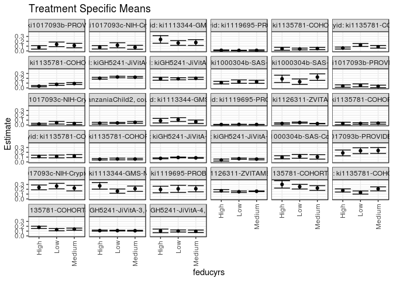

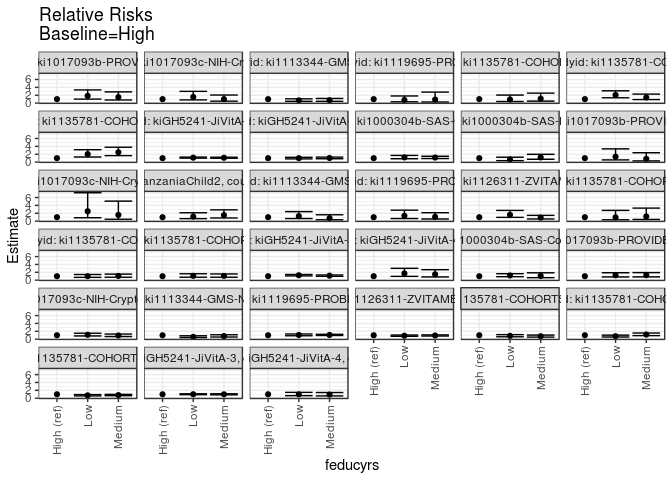

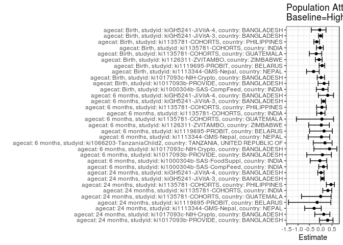

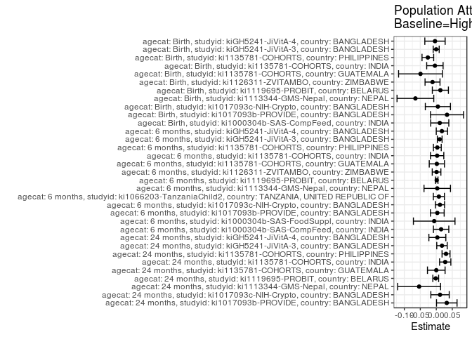

## Results Table

### Parameter: TSM

| agecat | studyid | country | intervention_level | baseline_level | estimate | ci_lower | ci_upper |
| --- | --- | --- | --- | --- | --- | --- | --- |
| Birth | ki1000304b-SAS-CompFeed | INDIA | High | NA | 0.0962963 | 0.0636749 | 0.1289177 |
| Birth | ki1000304b-SAS-CompFeed | INDIA | Low | NA | 0.1155462 | 0.0756810 | 0.1554114 |
| Birth | ki1000304b-SAS-CompFeed | INDIA | Medium | NA | 0.1042254 | 0.0592232 | 0.1492275 |
| Birth | ki1017093b-PROVIDE | BANGLADESH | High | NA | 0.1863354 | 0.1261330 | 0.2465378 |
| Birth | ki1017093b-PROVIDE | BANGLADESH | Low | NA | 0.2324324 | 0.1715100 | 0.2933549 |
| Birth | ki1017093b-PROVIDE | BANGLADESH | Medium | NA | 0.2365591 | 0.1754287 | 0.2976896 |
| Birth | ki1017093c-NIH-Crypto | BANGLADESH | High | NA | 0.2382671 | 0.1880619 | 0.2884724 |
| Birth | ki1017093c-NIH-Crypto | BANGLADESH | Low | NA | 0.2663755 | 0.2090799 | 0.3236712 |
| Birth | ki1017093c-NIH-Crypto | BANGLADESH | Medium | NA | 0.2238806 | 0.1662133 | 0.2815479 |
| Birth | ki1113344-GMS-Nepal | NEPAL | High | NA | 0.2716049 | 0.2030589 | 0.3401510 |
| Birth | ki1113344-GMS-Nepal | NEPAL | Low | NA | 0.1616541 | 0.1173798 | 0.2059285 |
| Birth | ki1113344-GMS-Nepal | NEPAL | Medium | NA | 0.2122642 | 0.1571772 | 0.2673511 |
| Birth | ki1119695-PROBIT | BELARUS | High | NA | 0.1950268 | 0.1264646 | 0.2635890 |
| Birth | ki1119695-PROBIT | BELARUS | Low | NA | 0.2089862 | 0.1356066 | 0.2823659 |
| Birth | ki1119695-PROBIT | BELARUS | Medium | NA | 0.2111037 | 0.1473025 | 0.2749049 |
| Birth | ki1126311-ZVITAMBO | ZIMBABWE | High | NA | 0.1695842 | 0.1452548 | 0.1939137 |
| Birth | ki1126311-ZVITAMBO | ZIMBABWE | Low | NA | 0.1492109 | 0.1339388 | 0.1644830 |
| Birth | ki1126311-ZVITAMBO | ZIMBABWE | Medium | NA | 0.1585493 | 0.1512303 | 0.1658683 |
| Birth | ki1135781-COHORTS | GUATEMALA | High | NA | 0.3014706 | 0.2242921 | 0.3786490 |
| Birth | ki1135781-COHORTS | GUATEMALA | Low | NA | 0.2540193 | 0.2056057 | 0.3024329 |
| Birth | ki1135781-COHORTS | GUATEMALA | Medium | NA | 0.2250923 | 0.1753333 | 0.2748512 |
| Birth | ki1135781-COHORTS | INDIA | High | NA | 0.1755424 | 0.1424150 | 0.2086698 |
| Birth | ki1135781-COHORTS | INDIA | Low | NA | 0.1328502 | 0.1001430 | 0.1655575 |
| Birth | ki1135781-COHORTS | INDIA | Medium | NA | 0.2081081 | 0.1667279 | 0.2494883 |
| Birth | ki1135781-COHORTS | PHILIPPINES | High | NA | 0.1770624 | 0.1533278 | 0.2007969 |
| Birth | ki1135781-COHORTS | PHILIPPINES | Low | NA | 0.1293661 | 0.1057033 | 0.1530289 |
| Birth | ki1135781-COHORTS | PHILIPPINES | Medium | NA | 0.1404787 | 0.1185052 | 0.1624522 |
| Birth | kiGH5241-JiVitA-3 | BANGLADESH | High | NA | 0.1094097 | 0.0985624 | 0.1202571 |
| Birth | kiGH5241-JiVitA-3 | BANGLADESH | Low | NA | 0.1099034 | 0.1021179 | 0.1176889 |
| Birth | kiGH5241-JiVitA-3 | BANGLADESH | Medium | NA | 0.1077395 | 0.0989567 | 0.1165224 |

[output cut: 69 more lines]

### Parameter: E(Y)

| agecat | studyid | country | intervention_level | baseline_level | estimate | ci_lower | ci_upper |
| --- | --- | --- | --- | --- | --- | --- | --- |
| Birth | ki1000304b-SAS-CompFeed | INDIA | NA | NA | 0.1071753 | 0.0763487 | 0.1380019 |
| Birth | ki1017093b-PROVIDE | BANGLADESH | NA | NA | 0.2199248 | 0.1846953 | 0.2551543 |
| Birth | ki1017093c-NIH-Crypto | BANGLADESH | NA | NA | 0.2432815 | 0.2116319 | 0.2749310 |
| Birth | ki1113344-GMS-Nepal | NEPAL | NA | NA | 0.2062500 | 0.1748784 | 0.2376216 |
| Birth | ki1119695-PROBIT | BELARUS | NA | NA | 0.2077971 | 0.1423827 | 0.2732114 |
| Birth | ki1126311-ZVITAMBO | ZIMBABWE | NA | NA | 0.1577985 | 0.1514260 | 0.1641709 |
| Birth | ki1135781-COHORTS | GUATEMALA | NA | NA | 0.2520891 | 0.2203065 | 0.2838718 |
| Birth | ki1135781-COHORTS | INDIA | NA | NA | 0.1711851 | 0.1506302 | 0.1917400 |
| Birth | ki1135781-COHORTS | PHILIPPINES | NA | NA | 0.1506598 | 0.1372339 | 0.1640858 |
| Birth | kiGH5241-JiVitA-3 | BANGLADESH | NA | NA | 0.1090574 | 0.1037994 | 0.1143154 |
| Birth | kiGH5241-JiVitA-4 | BANGLADESH | NA | NA | 0.0998709 | 0.0841992 | 0.1155426 |
| 6 months | ki1000304b-SAS-CompFeed | INDIA | NA | NA | 0.1239669 | 0.0988748 | 0.1490591 |
| 6 months | ki1000304b-SAS-FoodSuppl | INDIA | NA | NA | 0.1815789 | 0.1427684 | 0.2203895 |
| 6 months | ki1017093b-PROVIDE | BANGLADESH | NA | NA | 0.0414594 | 0.0255348 | 0.0573839 |
| 6 months | ki1017093c-NIH-Crypto | BANGLADESH | NA | NA | 0.0293706 | 0.0169860 | 0.0417552 |
| 6 months | ki1066203-TanzaniaChild2 | TANZANIA, UNITED REPUBLIC OF | NA | NA | 0.0431334 | 0.0342652 | 0.0520016 |
| 6 months | ki1113344-GMS-Nepal | NEPAL | NA | NA | 0.0905861 | 0.0668565 | 0.1143158 |
| 6 months | ki1119695-PROBIT | BELARUS | NA | NA | 0.0084166 | 0.0066777 | 0.0101555 |
| 6 months | ki1126311-ZVITAMBO | ZIMBABWE | NA | NA | 0.0307283 | 0.0270076 | 0.0344489 |
| 6 months | ki1135781-COHORTS | GUATEMALA | NA | NA | 0.0320442 | 0.0205636 | 0.0435248 |
| 6 months | ki1135781-COHORTS | INDIA | NA | NA | 0.1148014 | 0.0980067 | 0.1315962 |
| 6 months | ki1135781-COHORTS | PHILIPPINES | NA | NA | 0.0581577 | 0.0490934 | 0.0672220 |
| 6 months | kiGH5241-JiVitA-3 | BANGLADESH | NA | NA | 0.0845079 | 0.0795688 | 0.0894470 |
| 6 months | kiGH5241-JiVitA-4 | BANGLADESH | NA | NA | 0.0567164 | 0.0477001 | 0.0657328 |
| 24 months | ki1017093b-PROVIDE | BANGLADESH | NA | NA | 0.1070812 | 0.0818727 | 0.1322897 |
| 24 months | ki1017093c-NIH-Crypto | BANGLADESH | NA | NA | 0.0875486 | 0.0630907 | 0.1120065 |
| 24 months | ki1113344-GMS-Nepal | NEPAL | NA | NA | 0.1851852 | 0.1506144 | 0.2197560 |
| 24 months | ki1119695-PROBIT | BELARUS | NA | NA | 0.0111601 | 0.0050716 | 0.0172486 |
| 24 months | ki1135781-COHORTS | GUATEMALA | NA | NA | 0.0449102 | 0.0320802 | 0.0577401 |
| 24 months | ki1135781-COHORTS | INDIA | NA | NA | 0.0875912 | 0.0726161 | 0.1025664 |
| 24 months | ki1135781-COHORTS | PHILIPPINES | NA | NA | 0.0668392 | 0.0566723 | 0.0770060 |
| 24 months | kiGH5241-JiVitA-3 | BANGLADESH | NA | NA | 0.2187803 | 0.2086815 | 0.2288790 |
| 24 months | kiGH5241-JiVitA-4 | BANGLADESH | NA | NA | 0.1938288 | 0.1801571 | 0.2075004 |

### Parameter: RR

| agecat | studyid | country | intervention_level | baseline_level | estimate | ci_lower | ci_upper |
| --- | --- | --- | --- | --- | --- | --- | --- |
| Birth | ki1000304b-SAS-CompFeed | INDIA | High | High | 1.0000000 | 1.0000000 | 1.0000000 |
| Birth | ki1000304b-SAS-CompFeed | INDIA | Low | High | 1.1999030 | 0.8760028 | 1.6435646 |
| Birth | ki1000304b-SAS-CompFeed | INDIA | Medium | High | 1.0823402 | 0.6264565 | 1.8699786 |
| Birth | ki1017093b-PROVIDE | BANGLADESH | High | High | 1.0000000 | 1.0000000 | 1.0000000 |
| Birth | ki1017093b-PROVIDE | BANGLADESH | Low | High | 1.2473874 | 0.8228476 | 1.8909642 |
| Birth | ki1017093b-PROVIDE | BANGLADESH | Medium | High | 1.2695341 | 0.8393992 | 1.9200836 |
| Birth | ki1017093c-NIH-Crypto | BANGLADESH | High | High | 1.0000000 | 1.0000000 | 1.0000000 |
| Birth | ki1017093c-NIH-Crypto | BANGLADESH | Low | High | 1.1179701 | 0.8272984 | 1.5107694 |
| Birth | ki1017093c-NIH-Crypto | BANGLADESH | Medium | High | 0.9396201 | 0.6736358 | 1.3106279 |
| Birth | ki1113344-GMS-Nepal | NEPAL | High | High | 1.0000000 | 1.0000000 | 1.0000000 |
| Birth | ki1113344-GMS-Nepal | NEPAL | Low | High | 0.5951811 | 0.4101140 | 0.8637613 |
| Birth | ki1113344-GMS-Nepal | NEPAL | Medium | High | 0.7815180 | 0.5441575 | 1.1224147 |
| Birth | ki1119695-PROBIT | BELARUS | High | High | 1.0000000 | 1.0000000 | 1.0000000 |
| Birth | ki1119695-PROBIT | BELARUS | Low | High | 1.0715768 | 0.8658255 | 1.3262221 |
| Birth | ki1119695-PROBIT | BELARUS | Medium | High | 1.0824343 | 0.9419873 | 1.2438215 |
| Birth | ki1126311-ZVITAMBO | ZIMBABWE | High | High | 1.0000000 | 1.0000000 | 1.0000000 |
| Birth | ki1126311-ZVITAMBO | ZIMBABWE | Low | High | 0.8798630 | 0.7376964 | 1.0494276 |
| Birth | ki1126311-ZVITAMBO | ZIMBABWE | Medium | High | 0.9349296 | 0.8041308 | 1.0870039 |
| Birth | ki1135781-COHORTS | GUATEMALA | High | High | 1.0000000 | 1.0000000 | 1.0000000 |
| Birth | ki1135781-COHORTS | GUATEMALA | Low | High | 0.8426006 | 0.6123668 | 1.1593961 |
| Birth | ki1135781-COHORTS | GUATEMALA | Medium | High | 0.7466475 | 0.5323771 | 1.0471571 |
| Birth | ki1135781-COHORTS | INDIA | High | High | 1.0000000 | 1.0000000 | 1.0000000 |
| Birth | ki1135781-COHORTS | INDIA | Low | High | 0.7567986 | 0.5549589 | 1.0320478 |
| Birth | ki1135781-COHORTS | INDIA | Medium | High | 1.1855147 | 0.9012622 | 1.5594187 |
| Birth | ki1135781-COHORTS | PHILIPPINES | High | High | 1.0000000 | 1.0000000 | 1.0000000 |
| Birth | ki1135781-COHORTS | PHILIPPINES | Low | High | 0.7306245 | 0.5823824 | 0.9166008 |
| Birth | ki1135781-COHORTS | PHILIPPINES | Medium | High | 0.7933852 | 0.6456843 | 0.9748729 |
| Birth | kiGH5241-JiVitA-3 | BANGLADESH | High | High | 1.0000000 | 1.0000000 | 1.0000000 |
| Birth | kiGH5241-JiVitA-3 | BANGLADESH | Low | High | 1.0045119 | 0.8909896 | 1.1324983 |
| Birth | kiGH5241-JiVitA-3 | BANGLADESH | Medium | High | 0.9847343 | 0.8655960 | 1.1202705 |

[output cut: 69 more lines]

### Parameter: PAR

| agecat | studyid | country | intervention_level | baseline_level | estimate | ci_lower | ci_upper |
| --- | --- | --- | --- | --- | --- | --- | --- |
| Birth | ki1000304b-SAS-CompFeed | INDIA | High | NA | 0.0108790 | -0.0174190 | 0.0391770 |
| Birth | ki1017093b-PROVIDE | BANGLADESH | High | NA | 0.0335894 | -0.0180998 | 0.0852786 |
| Birth | ki1017093c-NIH-Crypto | BANGLADESH | High | NA | 0.0050143 | -0.0343197 | 0.0443483 |
| Birth | ki1113344-GMS-Nepal | NEPAL | High | NA | -0.0653549 | -0.1228362 | -0.0078737 |
| Birth | ki1119695-PROBIT | BELARUS | High | NA | 0.0127703 | -0.0123824 | 0.0379229 |
| Birth | ki1126311-ZVITAMBO | ZIMBABWE | High | NA | -0.0117858 | -0.0351625 | 0.0115909 |
| Birth | ki1135781-COHORTS | GUATEMALA | High | NA | -0.0493815 | -0.1180120 | 0.0192491 |
| Birth | ki1135781-COHORTS | INDIA | High | NA | -0.0043573 | -0.0300082 | 0.0212936 |
| Birth | ki1135781-COHORTS | PHILIPPINES | High | NA | -0.0264026 | -0.0446526 | -0.0081525 |
| Birth | kiGH5241-JiVitA-3 | BANGLADESH | High | NA | -0.0003523 | -0.0097679 | 0.0090633 |
| Birth | kiGH5241-JiVitA-4 | BANGLADESH | High | NA | -0.0040507 | -0.0358869 | 0.0277855 |
| 6 months | ki1000304b-SAS-CompFeed | INDIA | High | NA | 0.0150844 | -0.0089901 | 0.0391589 |
| 6 months | ki1000304b-SAS-FoodSuppl | INDIA | High | NA | -0.0065399 | -0.0716128 | 0.0585330 |
| 6 months | ki1017093b-PROVIDE | BANGLADESH | High | NA | 0.0031819 | -0.0183012 | 0.0246649 |
| 6 months | ki1017093c-NIH-Crypto | BANGLADESH | High | NA | 0.0114495 | -0.0029263 | 0.0258253 |
| 6 months | ki1066203-TanzaniaChild2 | TANZANIA, UNITED REPUBLIC OF | High | NA | 0.0080929 | -0.0092295 | 0.0254154 |
| 6 months | ki1113344-GMS-Nepal | NEPAL | High | NA | 0.0029949 | -0.0384231 | 0.0444130 |
| 6 months | ki1119695-PROBIT | BELARUS | High | NA | 0.0012510 | -0.0028115 | 0.0053135 |
| 6 months | ki1126311-ZVITAMBO | ZIMBABWE | High | NA | 0.0008513 | -0.0126618 | 0.0143644 |
| 6 months | ki1135781-COHORTS | GUATEMALA | High | NA | 0.0017412 | -0.0220695 | 0.0255519 |
| 6 months | ki1135781-COHORTS | INDIA | High | NA | 0.0026691 | -0.0181379 | 0.0234761 |
| 6 months | ki1135781-COHORTS | PHILIPPINES | High | NA | 0.0032250 | -0.0090258 | 0.0154757 |
| 6 months | kiGH5241-JiVitA-3 | BANGLADESH | High | NA | 0.0107547 | 0.0033826 | 0.0181268 |
| 6 months | kiGH5241-JiVitA-4 | BANGLADESH | High | NA | 0.0175543 | -0.0001385 | 0.0352471 |
| 24 months | ki1017093b-PROVIDE | BANGLADESH | High | NA | 0.0328237 | 0.0007103 | 0.0649372 |
| 24 months | ki1017093c-NIH-Crypto | BANGLADESH | High | NA | 0.0117193 | -0.0170383 | 0.0404768 |
| 24 months | ki1113344-GMS-Nepal | NEPAL | High | NA | -0.0537529 | -0.1209031 | 0.0133974 |
| 24 months | ki1119695-PROBIT | BELARUS | High | NA | -0.0017431 | -0.0108060 | 0.0073198 |
| 24 months | ki1135781-COHORTS | GUATEMALA | High | NA | -0.0000336 | -0.0276458 | 0.0275785 |
| 24 months | ki1135781-COHORTS | INDIA | High | NA | 0.0278897 | 0.0102309 | 0.0455486 |
| 24 months | ki1135781-COHORTS | PHILIPPINES | High | NA | 0.0304983 | 0.0180105 | 0.0429861 |
| 24 months | kiGH5241-JiVitA-3 | BANGLADESH | High | NA | 0.0178070 | 0.0014752 | 0.0341388 |
| 24 months | kiGH5241-JiVitA-4 | BANGLADESH | High | NA | 0.0033526 | -0.0231686 | 0.0298738 |

### Parameter: PAF

| agecat | studyid | country | intervention_level | baseline_level | estimate | ci_lower | ci_upper |
| --- | --- | --- | --- | --- | --- | --- | --- |
| Birth | ki1000304b-SAS-CompFeed | INDIA | High | NA | 0.1015066 | -0.1919814 | 0.3227324 |
| Birth | ki1017093b-PROVIDE | BANGLADESH | High | NA | 0.1527313 | -0.1172555 | 0.3574754 |
| Birth | ki1017093c-NIH-Crypto | BANGLADESH | High | NA | 0.0206112 | -0.1551712 | 0.1696448 |
| Birth | ki1113344-GMS-Nepal | NEPAL | High | NA | -0.3168724 | -0.6256271 | -0.0667594 |
| Birth | ki1119695-PROBIT | BELARUS | High | NA | 0.0614554 | -0.0680891 | 0.1752880 |
| Birth | ki1126311-ZVITAMBO | ZIMBABWE | High | NA | -0.0746889 | -0.2335071 | 0.0636810 |
| Birth | ki1135781-COHORTS | GUATEMALA | High | NA | -0.1958889 | -0.5013437 | 0.0474199 |
| Birth | ki1135781-COHORTS | INDIA | High | NA | -0.0254536 | -0.1867771 | 0.1139405 |
| Birth | ki1135781-COHORTS | PHILIPPINES | High | NA | -0.1752461 | -0.3021912 | -0.0606763 |
| Birth | kiGH5241-JiVitA-3 | BANGLADESH | High | NA | -0.0032306 | -0.0933886 | 0.0794932 |
| Birth | kiGH5241-JiVitA-4 | BANGLADESH | High | NA | -0.0405595 | -0.4126655 | 0.2335312 |
| 6 months | ki1000304b-SAS-CompFeed | INDIA | High | NA | 0.1216810 | -0.0852953 | 0.2891849 |
| 6 months | ki1000304b-SAS-FoodSuppl | INDIA | High | NA | -0.0360166 | -0.4641194 | 0.2669105 |
| 6 months | ki1017093b-PROVIDE | BANGLADESH | High | NA | 0.0767464 | -0.6169746 | 0.4728444 |
| 6 months | ki1017093c-NIH-Crypto | BANGLADESH | High | NA | 0.3898276 | -0.3012672 | 0.7138863 |
| 6 months | ki1066203-TanzaniaChild2 | TANZANIA, UNITED REPUBLIC OF | High | NA | 0.1876259 | -0.3290219 | 0.5034305 |
| 6 months | ki1113344-GMS-Nepal | NEPAL | High | NA | 0.0330614 | -0.5514148 | 0.3973435 |
| 6 months | ki1119695-PROBIT | BELARUS | High | NA | 0.1486365 | -0.4930504 | 0.5145377 |
| 6 months | ki1126311-ZVITAMBO | ZIMBABWE | High | NA | 0.0277044 | -0.5283431 | 0.3814486 |
| 6 months | ki1135781-COHORTS | GUATEMALA | High | NA | 0.0543365 | -1.0743176 | 0.5688801 |
| 6 months | ki1135781-COHORTS | INDIA | High | NA | 0.0232496 | -0.1758710 | 0.1886514 |
| 6 months | ki1135781-COHORTS | PHILIPPINES | High | NA | 0.0554519 | -0.1803368 | 0.2441385 |
| 6 months | kiGH5241-JiVitA-3 | BANGLADESH | High | NA | 0.1272626 | 0.0349908 | 0.2107116 |
| 6 months | kiGH5241-JiVitA-4 | BANGLADESH | High | NA | 0.3095100 | -0.1027149 | 0.5676340 |
| 24 months | ki1017093b-PROVIDE | BANGLADESH | High | NA | 0.3065315 | -0.0574348 | 0.5452215 |
| 24 months | ki1017093c-NIH-Crypto | BANGLADESH | High | NA | 0.1338599 | -0.2629839 | 0.4060109 |
| 24 months | ki1113344-GMS-Nepal | NEPAL | High | NA | -0.2902655 | -0.7067376 | 0.0245806 |
| 24 months | ki1119695-PROBIT | BELARUS | High | NA | -0.1561890 | -1.4222360 | 0.4481243 |
| 24 months | ki1135781-COHORTS | GUATEMALA | High | NA | -0.0007491 | -0.8498780 | 0.4586137 |
| 24 months | ki1135781-COHORTS | INDIA | High | NA | 0.3184080 | 0.0925022 | 0.4880784 |
| 24 months | ki1135781-COHORTS | PHILIPPINES | High | NA | 0.4562940 | 0.2504808 | 0.6055921 |
| 24 months | kiGH5241-JiVitA-3 | BANGLADESH | High | NA | 0.0813922 | 0.0037542 | 0.1529799 |
| 24 months | kiGH5241-JiVitA-4 | BANGLADESH | High | NA | 0.0172966 | -0.1296467 | 0.1451256 |